# <<<<<<< HEAD La sociología chilena entre 2000-2021 en Web of Science: un análisis computacional de texto

## 2.2 Structural Topic Modeling

El presente análisis identifica 10 temáticas principales en la producción sociológica chilena de alcance internacional, haciendo uso de análisis automatizado de texto, utilizando un *structural topic model* producido con el paquete *stm 1.3.6*, desarrollado por Roberts, Stewart y Tingley (2014), en RStudio.

En el *Topic Modeling* los temas se crean automáticamente y a partir de los datos empíricos, basándose en el recuento de términos, sin importar su orden ni relación con otras palabras —método bag-of-words—. En este sentido, permite el procesamiento de grandes volúmenes de texto, si bien sus resultados requieren interpretación (Chang et al., 2009). El *Structural Topic Modeling* además incorpora variables la forma en que el texto cambia en función de los metadatos del texto, en tanto covariables (Roberts et al., 2014).

Tras la selección del modelo definitivo, en respuesta a la primera interrogante de este estudio, se identifica la proporción de cada temática latente en la muestra. Respecto a la segunda pregunta de investigación, se calcularon las covariaciones temáticas en los documentos, generando un gráfico utilizando el algoritmo Fruchterman-Reingold disponible en el paquete *igraph R*. Finalmente, en respuesta a la tercera pregunta de investigación, se exploraron las relaciones entre las proporciones latentes de temáticas y los metadatos observados (publicación, idioma de publicación y citas).

# 3 Análisis

## 3.1 Temáticas

La **figura 1** presenta los 10 temas producidos por el modelo no supervisado, incluyendo los seis principales términos asociados a cada tema, ordenados de mayor a menor prevalencia en en el corpus.

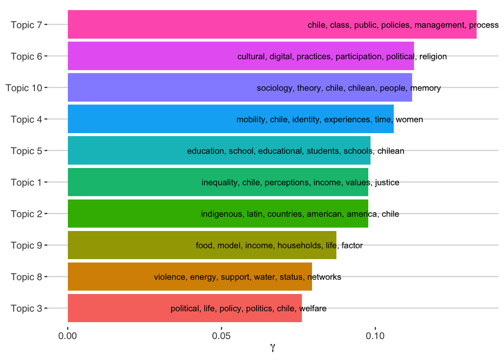

**Figura 1**: Las diez temáticas con mayor prevalencia en la muestra. El eje de abscisas señala la proporción de cada tema en el conjunto del corpus. Incluye los principales términos que contribuyen a cada temática. *Fuente*: Elaboración propia.

```r
quartz()
gamma_terms %>%
  top_n(10, gamma) %>%
  ggplot(aes(topic, gamma, label = terms, fill = topic)) +
  geom_col(show.legend = FALSE) +
  geom_text(hjust = 0.85, nudge_y = 0.0005, size = 3) +
  coord_flip() +
  theme_hc() +
  theme(plot.title = element_text(size = 14)) +
  labs(x = NULL, y = expression(gamma))
```

En este modelo, el Topic 7, que abarca clases sociales, políticas públicas y gestión en Chile, es la temática más prevalente en el corpus, representando casi un 13.28% de la presencia temática en todos los abstract y palabras clave.

## 3.2 Relación entre las temáticas

Se puede examinar cómo las temáticas se correlacionan entre sí a través de la co-ocurrencia de temáticas a nivel de texto. Esto permite explorar la probabilidad de que un solo documento discuta un determinado conjunto de temas. Estas correlaciones se exploran de forma gráfica en la **Figura 2**. Se puede observar la falta de nexos entre los nodos temáticos, esto implica que las correlaciones entre temáticas son menores a 0.01 en todos los casos. Esto implica el hecho de que los abstract y palabras clave de los artículos tienden a utilizar un lenguaje que no se utiliza habitualmente en los artículos de las otras temáticas. En cuanto a la distancia entre los nodos, se puede apreciar que si bien algunos tópicos se acercan en cierto grado (Topic 1, Topic 7 y Topic 2), no es posible identificar agrupación en clusters.

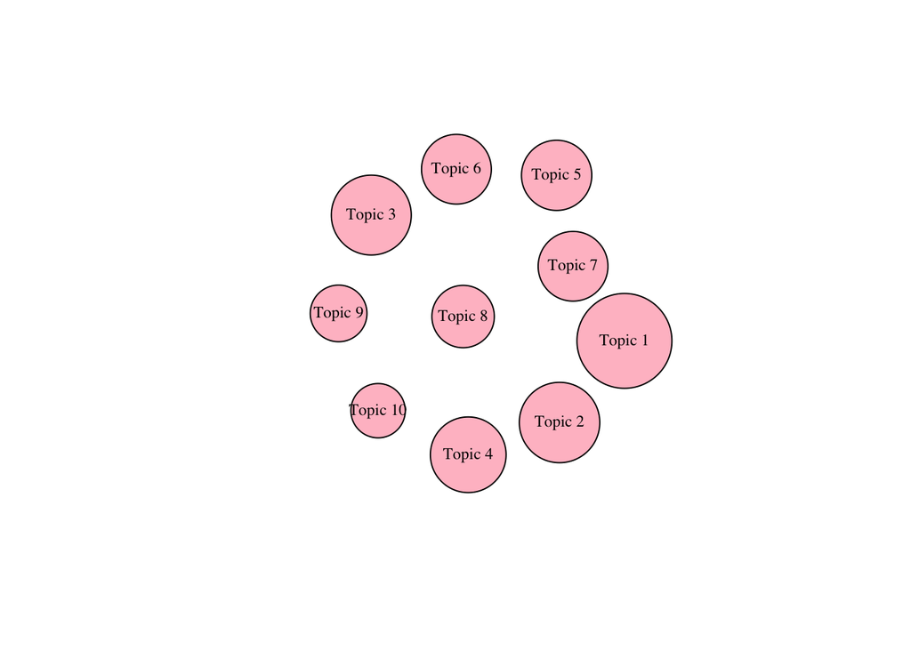

```r
topicCorr <- topicCorr(ten_topics, method = "simple", cutoff = 0.01)
plot(
  topicCorr,
  vertex.color = "pink",
  vertex.label.cex = 0.75,
  vertex.label.color = "black",
  vertex.size = 500 * (gamma_terms$gamma))
```

## 3.3 Efectos de otras variables en las temáticas

```r
efecto_year <-
  estimateEffect(
    1:10 ~ year,
    ten_topics,
    wos_tokens %>% distinct(ID, year) %>% arrange(ID))
# tidy(efecto_year)
# no se observan diferencias estadisticamente significativas por ano en ningun topic (CI 0.95)

efecto_cite <-
  estimateEffect(
    1:10 ~ citations,
    ten_topics,
    wos_tokens %>% distinct(ID, citations) %>% arrange(ID))
# tidy(efecto_cite)
# no se observan diferencias estadisticamente significativas por cantidad de citas promedio en ningun topic (CI 0.95)

efecto_lang <-
  estimateEffect(
    1:10 ~ idioma,
    ten_topics,
    wos_tokens %>% distinct(ID, idioma) %>% arrange(ID))
# tidy(efecto_lang)
# no se observan diferencias estadisticamente significativas por idioma de la publicacion en ningun topic (CI 0.95)
```

Además de la prevalencia de los tópicos y la correlación entre ellos, se evaluó la asociación de las temáticas al año de publicación, la cantidad de citas y el idioma de publicación de los textos. En ninguno de los casos estimados se puede probar la predictividad, ya que a pesar de tener variaciones observables en los beta de regresión, no se puede afirmar que sean estadísticamente significativas con un 95% de confianza.

# 4 Discusión

A partir del structural topic model producido en esta investigación, se identificaron 10 temáticas presentes en la producción sociológica chilena de alcance internacional, entre 2001 y 2021. Entre estas temáticas se pudo identificar una mayor prevalencia de ciertos tópicos en el corpus, si bien no se pudo identificar correlación entre dichos tópicos ni su correlación con otras variables explicativas. Respecto a la falta de relación entre temáticas (Figura 2), se abre la duda respecto a la cantidad de temáticas consideradas en el modelos, pudiendo efectivamente ser cada Topic un cluster de temáticas de investigación más específicas y con mayor coherencia interna. Esta posibilidad es aún más llamativa considerando la falta de cohesión temática en las temáticas de mayor prevalencia (Figura 1) En esta línea, se identifica la posibilidad de estimar nuevamente un structural topic model, con una mayor cantidad de tópicos (K), que permita describir con mayor precisión las tendencias de producción sociológica chilena, así como explorar su dimensionalidad.